# Lecture 502 Univariate analysis

## Checking assumptions

- **Linearity**
  - the relationship is actually linear
- **Normality** of residuals
  - standard residuals are normally distributed with mean `0`
- **Homoscedasticity** of residuals
  - at each level of the predictor variable(s) the variance of the standard residuals should be the same (*homo-scedasticity*) rather than different (*hetero-scedasticity*)
- **Independence** of residuals
  - adjacent standard residuals are not correlated
- When more than one predictor: **no multicollinearity**
  - if two or more predictor variables are used in the model, each pair of variables not correlated

## Normality

Shapiro-Wilk test for normality of standard residuals,

- robust models: should be not significant

```r
delay_model %>%
  rstandard() %>%
  shapiro.test()
```

```
##
##  Shapiro-Wilk normality test
##
## data:  .
## W = 0.98231, p-value = 1.73e-09
```

**Standard residuals are NOT normally distributed**

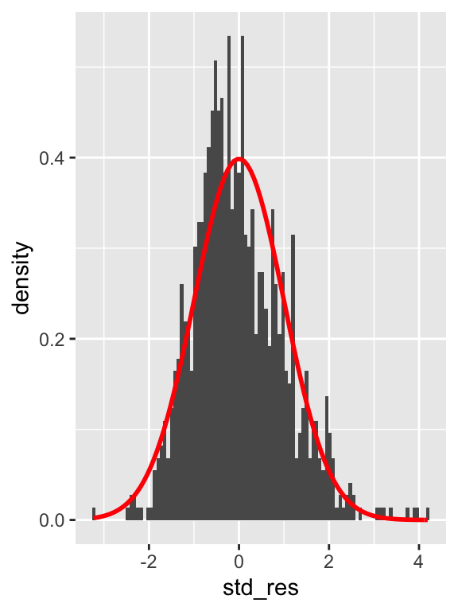

## Homoscedasticity

Breusch-Pagan test for homoscedasticity of standard residuals

- robust models: should be not significant

```r
library(lmtest)

delay_model %>%
  bptest()
```

```
##
##  studentized Breusch-Pagan test
##
## data:  .
## BP = 0.017316, df = 1, p-value = 0.8953
```

**Standard residuals are homoscedastic**

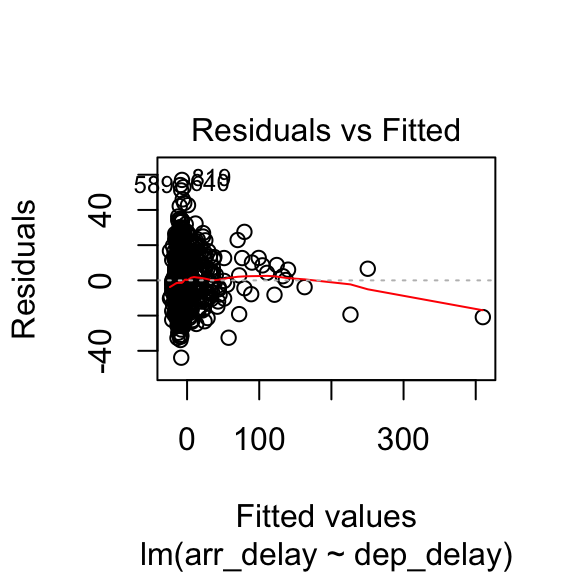

## Independence

Durbin-Watson test for the independence of residuals

- robust models: statistic should be close to 2 (between 1 and 3) and not significant

```r
# Also part of the library lmtest
delay_model %>%
  dwtest()
```

```
##
##  Durbin-Watson test
##
## data:  .
## DW = 1.8731, p-value = 0.02358
## alternative hypothesis: true autocorrelation is greater than 0
```

**Standard residuals might not be completely indipendent**

Note: the result depends on the order of the data.

## Lecture 502 Summary

## Summary

- Comparing means
  - t-test
  - ANOVA
- Correlation
  - Pearson’s r
  - Spearman’s rho
  - Kendall’s tau
- Regression
  - univariate

## Practical session

In the practical session, we will see:

- Comparing means
  - ANOVA
- Regression
  - univariate
  - multivariate

## Next lecture

- Machine Learning
  - Definition
  - Types
- Unsupervised
  - Clustering
- In GIScience
  - Geodemographic classification